# Reproducible Research Course Project

Dhilen Shah

September 30, 2016

## Loading and preprocessing the data

Download and load data into data frame `data`.

```r
if(!file.exists("getdata-projectfiles-UCI HAR Dataset.zip")) {

 file-> download.file("http://d396qusza40orc.cloudfront.net/repdata%2Fdata%2Factivity.zip",temp)
  unzip(file)
  unlink(temp)
}

df <- read.csv("activity.csv")
```

## What is mean total number of steps taken per day?

Sum steps by day, create Histogram, and calculate mean and median.

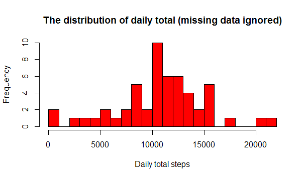

plot of Image 1

```r
df$date <- as.Date(df$date)
df_ign <- subset(df, !is.na(df$steps))

dailysum <- tapply(df_ign$steps, df_ign$date, sum, na.rm=TRUE, simplify=T)
dailysum <- dailysum[!is.na(dailysum)]

hist(x=dailysum,
     col="red",
     breaks=20,
     xlab="Daily total steps",
     ylab="Frequency",
     main="The distribution of daily total (missing data ignored)")
```

```r
mean(dailysum)
## [1] 10766

median(dailysum)
## [1] 10765
```

So the mean is 10766 steps and the median is 10765 steps.

## What is the average daily activity pattern?

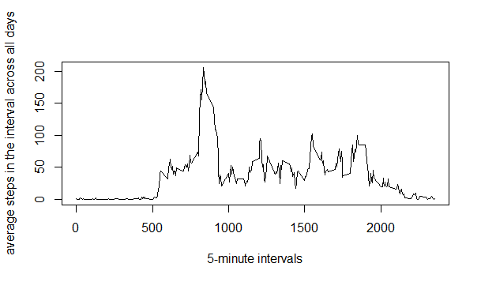

plot of Image 2

```r
int_avg <- tapply(df_ign$steps, df_ign$interval, mean, na.rm=TRUE, simplify=T)
df_ia <- data.frame(interval=as.integer(names(int_avg)), avg=int_avg)

with(df_ia,
     plot(interval,
          avg,
          type="l",
          xlab="5-minute intervals",
          ylab="average steps in the interval across all days"))
```

Next is to check which 5-minute interval, on average across all the days in the dataset, contains the maximum number of steps:

```r
max_steps <- max(df_ia$avg)
df_ia[df_ia$avg == max_steps, ]
```

```
 interval   avg
    835    206.2
```

It turns out that the interval 835 contains maximum number of steps 206 .

## Impute missing values. Compare imputed to non-imputed data.

First, we calculate and report the total number of missing values in the dataset (i.e. the total number of rows with NAs):

```r
sum(is.na(df$steps))
```

[1] 2304 So the original data set has 2304 rows with missing data.

We use a simple strategy for filling in all of the missing values in the dataset. If a 5-minute interval has missing value, we use the mean for that 5-minute interval.

We create a new data frame df_impute that is equal to the original dataset but with the missing data filled in (using mean for that interval for imputation):

```r
df_impute <- df
ndx <- is.na(df_impute$steps)
int_avg <- tapply(df_ign$steps, df_ign$interval, mean, na.rm=TRUE, simplify=T)
df_impute$steps[ndx] <- int_avg[as.character(df_impute$interval[ndx])]
```

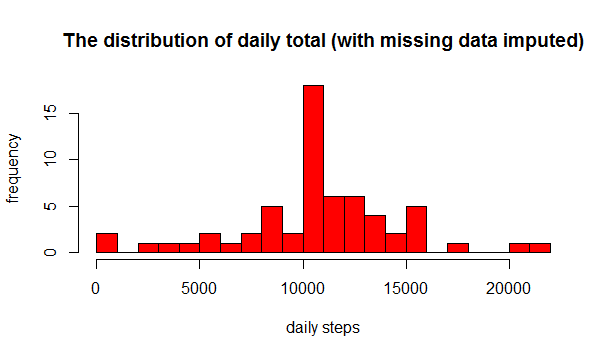

plot of Image 3

```r
new_dailysum <- tapply(df_impute$steps, df_impute$date, sum, na.rm=TRUE, simplify=T)

hist(x=new_dailysum,
     col="red",
     breaks=20,
     xlab="daily steps",
     ylab="frequency",
     main="The distribution of daily total (with missing data imputed)")
```

```r
mean(new_dailysum)
```

## [1] 10766

```r
median(new_dailysum)
```

## [1] 10766

Based on the imputed data set, the new mean is 10766 and the new median is 10766.Compare with the original mean 10766 and median 10765 , the mean doesn’t change, and the median has a small change. In fact, the new median becomes identical to the mean. One possible explanation is that when we fill the missing data for the intervals, we use means for intervals, so we have more data close or identical to the means, and median is shifted and becomes identical to the mean.

The impact of imputing missing data on the estimates of the total daily number of steps is also clear: now we have higher frquency counts in the histogram at the center region (close to the mean).

## Are there differences in activity patterns between weekdays and weekends?

First we create a new factor variable “wk” in the dataset with two levels - “weekday” and “weekend” indicating whether a given date is a weekday or weekend day.

# helper function to decide if a day is a week day or not

```r
is_weekday <- function(d) {
    wd <- weekdays(d)
    ifelse (wd == "Saturday" | wd == "Sunday", "weekend", "weekday")
}
```

```r
wx <- sapply(df_impute$date, is_weekday)
df_impute$wk <- as.factor(wx)
head(df_impute)
```

```
  steps       date interval      wk
```

## 1 1.71698 2012-10-01 0 weekday

## 2 0.33962 2012-10-01 5 weekday

## 3 0.13208 2012-10-01 10 weekday

## 4 0.15094 2012-10-01 15 weekday

## 5 0.07547 2012-10-01 20 weekday

## 6 2.09434 2012-10-01 25 weekday

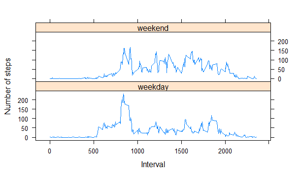

plot of Image 4

From the panel plot it looks like the weekday activities arise earlier than the weekends - weekday activities arise around 5~6am and weekend activities arise around 8am. We can also observe that from 10am to 5pm, the weekends have higher activity levels than the weekdays.